# hclust 对象里究竟有什么？

顾祖光

2023-07-07

等级聚类或者层级聚类是常用的数据分析方法，在R中，我们使用`hclust()`函数进行聚类分析。`hclust()`返回一个`hclust`类的对象。在本文中，让我们来揭开`hclust`对象的真面目。

首先生成一个随机的5x5矩阵，我们对矩阵的行进行聚类。

```r
set.seed(123456)
m = matrix(rnorm(25), 5)
rownames(m) = letters[1:5]
hc = hclust(dist(m))
```

`hc`属于一个`hclust`的类。输入`hc`变量名打印出这个变量的一些基本信息。

```r
hc
```

```
##
## Call:
## hclust(d = dist(m))
##
## Cluster method   : complete
## Distance         : euclidean
## Number of objects: 5
```

基本上就告诉你这是一个黑盒子，不告诉你其内部的结构。使用`plot()`函数可以绘制聚类图。

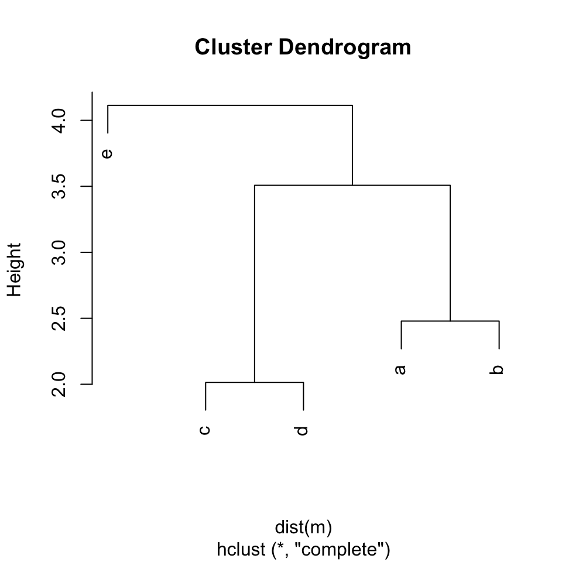

```r
plot(hc)
```

上面这两步是最标准的进行等级聚类分析的步骤，那么，`hc`变量中到底存储着什么信息呢？ 本文就来揭示这个`hc`变量的内部结构。在遇到任何一个未知格式的对象时，一般我们使用`str()`来展示其内部结构：

```r
str(hc)
```

```
## List of 7
##  $ merge      : int [1:4, 1:2] -3 -1 1 -5 -4 -2 2 3
##  $ height     : num [1:4] 2.01 2.48 3.51 4.11
##  $ order      : int [1:5] 5 3 4 1 2
##  $ labels     : chr [1:5] "a" "b" "c" "d" ...
##  $ method     : chr "complete"
##  $ call       : language hclust(d = dist(m))
##  $ dist.method: chr "euclidean"
##  - attr(*, "class")= chr "hclust"
```

可以看到，`hc`只是一个包含7个成员的简单列表。最后三个成员`method`，`call`和`dist.method`只是关于此变量的一些文字标记，我们跳过不谈。我们主要看前四个成员。

为了正确理解`hc`的格式，我们要对其中成员向量或者矩阵的顺序额外注意。我们首先介绍`labels`和`order`成员。

```r
hc$labels
```

```
## [1] "a" "b" "c" "d" "e"
```

```r
hc$order
```

```
## [1] 5 3 4 1 2
```

`labels`成员包含了原始变量的文字标签，其顺序和原始变量的顺序一致。在这里`hc`是来源于矩阵`m`，那么`labels`中值的顺序和`m`行的顺序一致。如果原始矩阵没有行名的话，`labels`是一个长度为零的向量。

`order`的顺序和`labels`不一样。等级聚类会对变量进行重排序，那么`order`中记录了排完序之后变量的下标。

```r
hc$order
```

```
## [1] 5 3 4 1 2
```

第一个元素表示聚完类后，变量5在第一个位置上，变量3在第二个位置上，以此类推。如果我们使用原始矩阵的行名的话，聚类之后的顺序为：

```r
hc$labels[hc$order]
```

```
## [1] "e" "c" "d" "a" "b"
```

也就是说，聚类之后，变量`"e"`在最左侧，然后分别是`"c"`, `"d"`, `"a"`和`"b"`。

现在让我们来看看`merge`和`height`成员。

```r
hc$merge
```

```
##      [,1] [,2]
## [1,]   -3   -4
## [2,]   -1   -2
## [3,]    1    2
## [4,]   -5    3
```

```r
hc$height
```

```
## [1] 2.014138 2.478801 3.507676 4.113743
```

第一眼看`hc$merge`，我们可能会说这是什么鬼，既有正的整数，又有负的整数。其实，`merge`使用不同的符号来表示聚类过程中不同类型的“节点”，比如说，这是一个变量/叶节点呢，还是一个子聚类/子树节点？

首先我们要知道，`hclust()`执行的是聚集式的聚类方式，也就是自底而上的方式。下图展示了`hc`中的四步聚类：

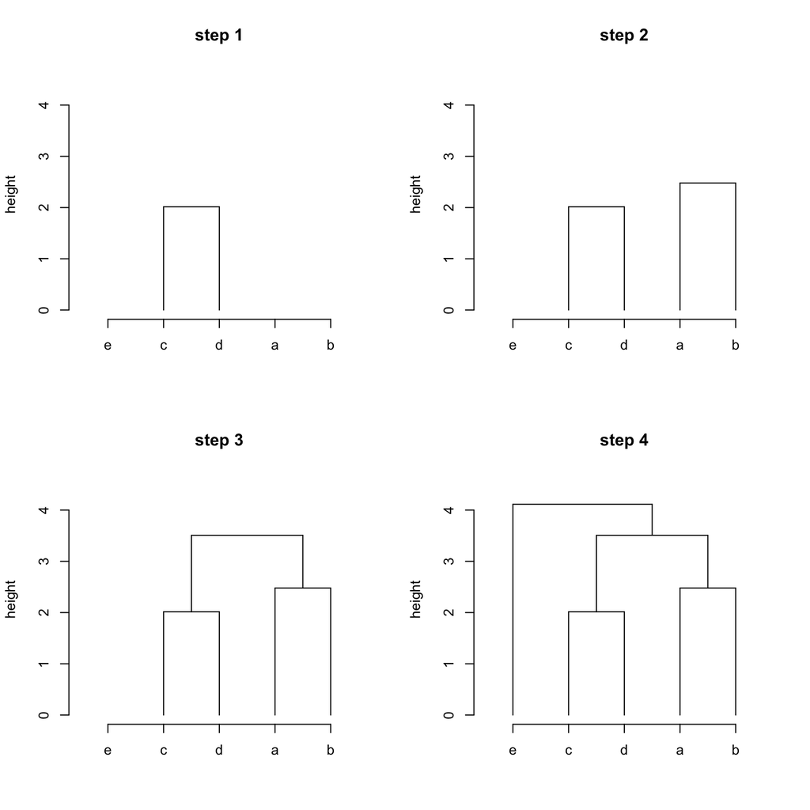

那么，其实`merge`中记录了聚类的步骤，第一行为聚类的第一步，第二行为聚类的第二步。每一行包含两个数据，表示把两个子节点聚成一类。其中如果值为负数时，这表示这是一个变量（或叶节点），那么其绝对值对应着这个变量的下标（第几号变量）；如果值为正数的话，这表示这是一个子树，值对应着子树在`merge`中的下标（第几号子树）。

现在`merge`可以读作：

```r
hc$merge
```

```
##      [,1] [,2]
## [1,]   -3   -4
## [2,]   -1   -2
## [3,]    1    2
## [4,]   -5    3
```

- 聚类第一步/`merge`中第一行：变量3（`"c"`)和变量4（`"d"`）聚成一类。这个子树（或者可以看成变量3和4的父节点）的编号为1（因为是`merge`中的第一行）。
- 聚类第二步/`merge`中第二行：变量1（`"a"`)和变量2（`"b"`）聚成一类。这个子树的编号为2。
- 聚类第三步/`merge`中第三行：现在这行的两个数字都是正数，这表示要合并的两个都是聚类的子树，编号为1和2。这两个在前两步已经生成。
- 聚类第四步/`merge`中第四行：这里有一个负数和一个正数，这表示要合并的是一个变量（变量5，`"e"`）和一个子树（编号为3，在第三步中生成）。

`hc$height`中的元素和`hc$merge`中的行对应，就是每一个子树的高度。

现在看来，`hclust`对象的格式还是很简单的。

我们可以试着基于`hc`的内部格式绘制聚类图。让我们按照`hc$merge`中所记录的聚类的步骤一步一步来绘制。

第一步是绘制合并3号变量和4号变量的子树，我们知道这个子树的高度是`hc$height[1]`，但是现在缺的是这些变量或者子树在x轴上的位置。这些位置很容易获得。

我们知道下面标签的顺序和聚类图上的顺序一致：

```r
hc$labels[hc$order]
```

```
## [1] "e" "c" "d" "a" "b"
```

也就是说，`"e"`在位置1，`"c"`在位置2，… 但是这五个标签的顺序并不是原始顺序。在`hc$merge`中，其中的整数对应的是变量的原始顺序，例如-2表示在原始顺序中的2号变量。那么我们需要一个变量，其中记录着每个变量在聚类图上的位置，并且处于原始顺序中（也就是对应`"a"`, `"b"`, `"c"`, `"d"`, `"e"`）。

我们可以首先创建一个有名字的向量，其中聚类之后的位置为值，名字为变量的标签。

```r
# 1:5 是在x轴上的位置
map = structure(1:5, names = hc$labels[hc$order])
# 然后我们用这个有名字的向量获得对应原始顺序的变量
x = map[hc$labels]
x
```

```
## a b c d e
## 4 5 2 3 1
```

其实我们可以直接取`hc$order`的order获得这个向量。

```r
x = order(hc$order)
x
```

```
## [1] 4 5 2 3 1
```

看起来有点绕，什么叫order的order？在`hc$order`中，值是变量的原始下标（也就是第几个变量），`hc$order`的下标（也就是1, 2, 3, 4, 5）对应着在聚完类后变量在x轴上的位置。

```
hc$order
  value 5 3 4 1 2  # indices of items, i.e. item 5, item 3, ...
  pos   1 2 3 4 5  # pos in x-axis in the plot
```

那么如果我们对`hc$order`（值为`5, 3, 4, 1, 2`）进行第二次`order()`时，在返回的变量中，第一个值是`5, 3, 4, 1, 2`中最小值的位置，就是1（1号变量）的位置是4（这个4是变量1在x轴上的位置），第二个值就是2（2号变量）的位置是5（变量2在x轴上的位置）。以此类推。这就意味着，`order(hc$order)`能够返回变量在聚类图上的位置，并且处于原始顺序中。

OK，现在我们有了所有的信息，可以一步一步的绘制聚类图了。我们按照`hc$merge`中的顺序：

第一步/对应着`hc$merge`中的第一行，我们画一条线连接3号变量（`"c"`）和4号变量（`"d"`）。

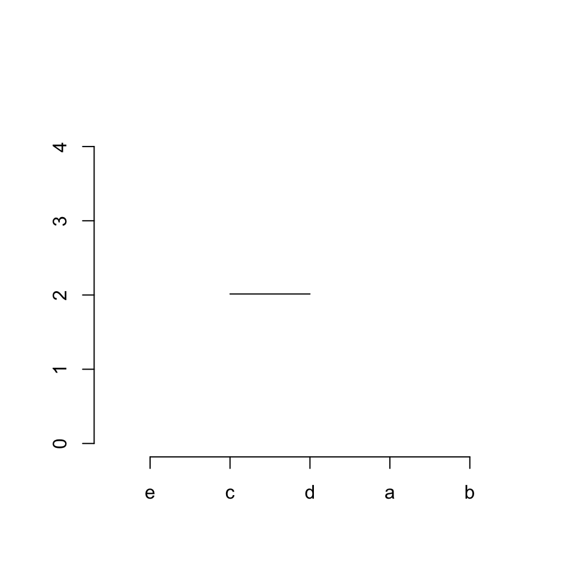

```r
plot(NULL, xlim = c(0.5, 5.5), ylim = c(0, max(hc$height)*1.1), axes = FALSE, ann = FALSE)
axis(side = 1, at = 1:5, labels = hc$labels[hc$order])
axis(side = 2)

# the first row in `merge` is '[1,]   -3   -4'
segments(x[3], hc$height[1], x[4], hc$height[1])
```

第二步/对应着`hc$merge`中的第二行，我们画一条线连接1号变量（`"a"`）和2号变量（`"b"`）。

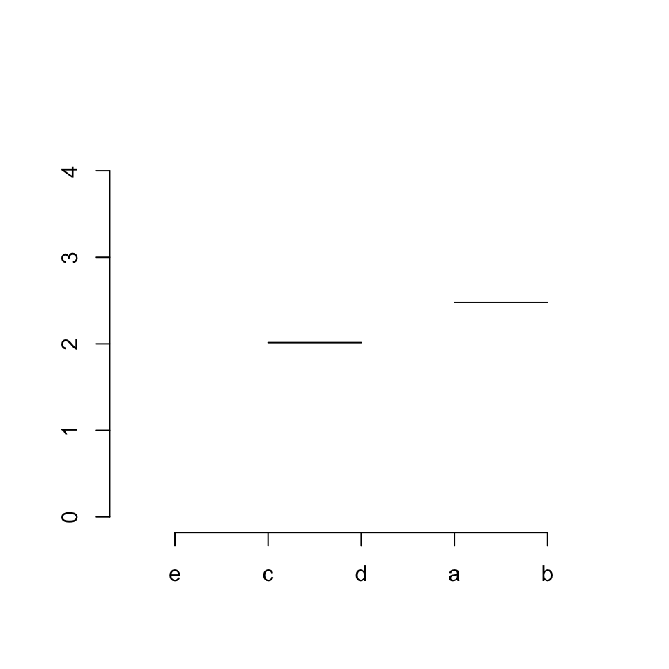

```r
plot(NULL, xlim = c(0.5, 5.5), ylim = c(0, max(hc$height)*1.1), axes = FALSE, ann = FALSE)
axis(side = 1, at = 1:5, labels = hc$labels[hc$order])
axis(side = 2)

segments(x[3], hc$height[1], x[4], hc$height[1])
# the second row in `merge` is '[2,]   -1   -2'
segments(x[1], hc$height[2], x[2], hc$height[2])
```

第三步/对应着`hc$merge`中的第三行。现在这里有个新情况，第三步我们需要合并两个子树，我们通常连接两个子树的中点。计算子树1和子树2的中点很容易。子树1的中点就是其两个子节点（变量3和变量4）的中点，子树2的中点就是其两个子节点（变量1和变量2）的中点。

在下面的代码中，变量`midpoint`记录了中点的位置。

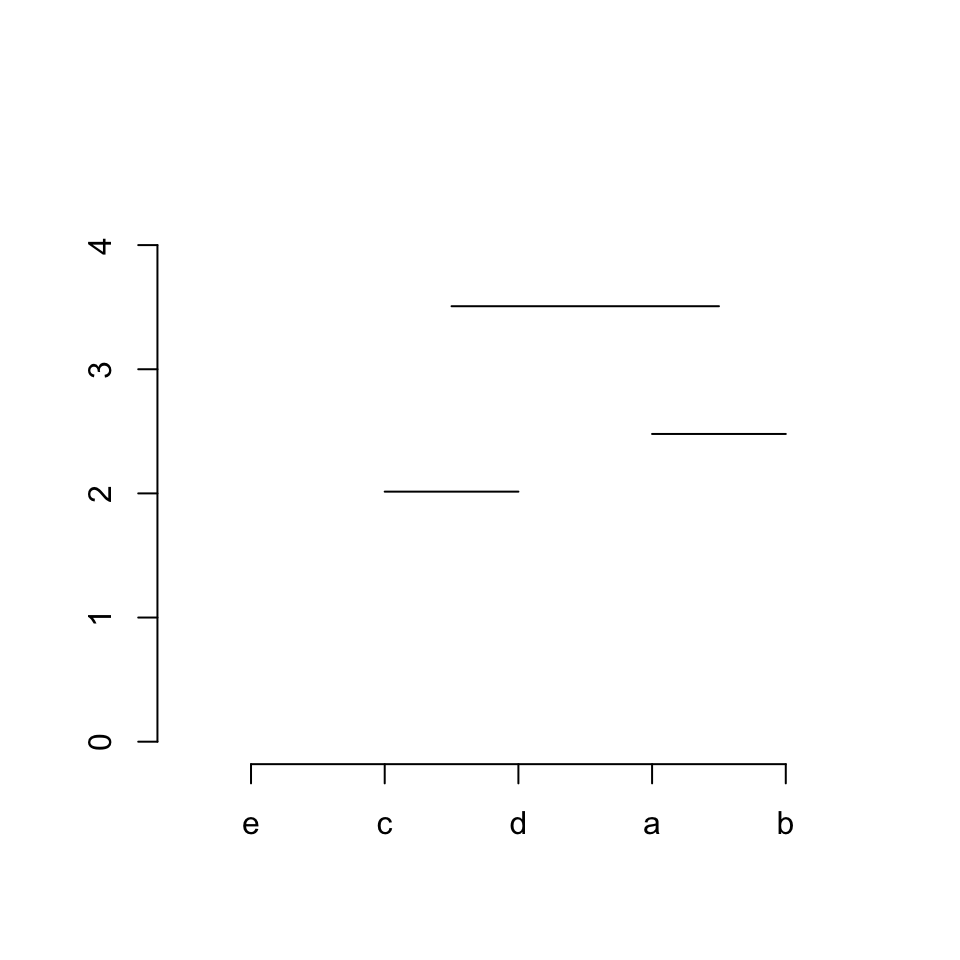

```r
plot(NULL, xlim = c(0.5, 5.5), ylim = c(0, max(hc$height)*1.1), axes = FALSE, ann = FALSE)
axis(side = 1, at = 1:5, labels = hc$labels[hc$order])
axis(side = 2)

segments(x[3], hc$height[1], x[4], hc$height[1])
segments(x[1], hc$height[2], x[2], hc$height[2])

midpoint = numeric(0)
midpoint[1] = (x[3]+x[4])/2
midpoint[2] = (x[1]+x[2])/2

# the third row in `merge` is '[3,]    1    2'
segments(midpoint[1], hc$height[3], midpoint[2], hc$height[3])
```

第四步/对应着`hc$merge`中的第四行。这一步合并5号变量和3号子树，同样我们需要先获得3号子树的中点（3号子树的中点是其两个子节点中点`midpoint[1]`和`midpoint[2]`的中点，看代码一目了然）。

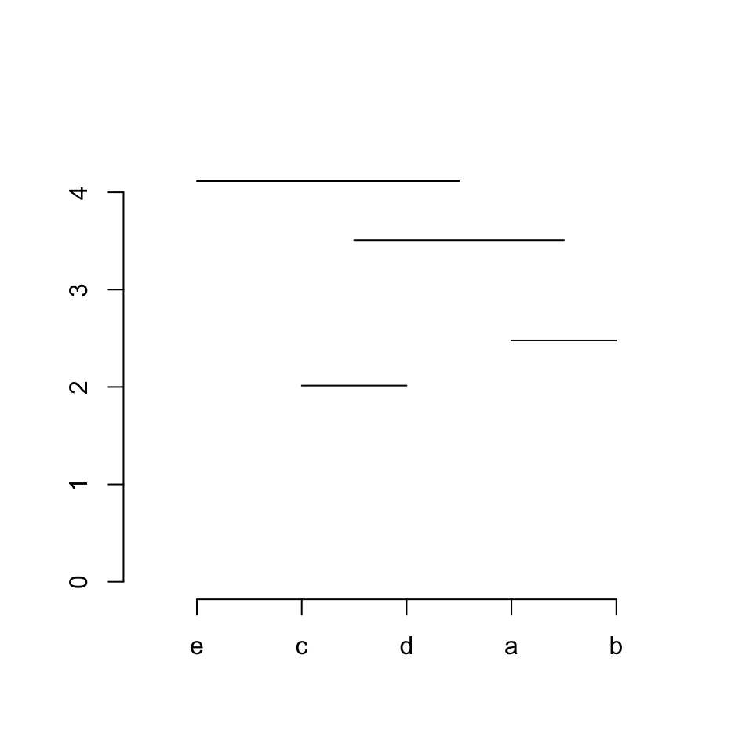

```r
plot(NULL, xlim = c(0.5, 5.5), ylim = c(0, max(hc$height)*1.1), axes = FALSE, ann = FALSE)
axis(side = 1, at = 1:5, labels = hc$labels[hc$order])
axis(side = 2)

segments(x[3], hc$height[1], x[4], hc$height[1])
segments(x[1], hc$height[2], x[2], hc$height[2])

midpoint = numeric(0)
midpoint[1] = (x[3]+x[4])/2
midpoint[2] = (x[1]+x[2])/2

segments(midpoint[1], hc$height[3], midpoint[2], hc$height[3])

midpoint[3] = (midpoint[1] + midpoint[2])/2
# the third row in `merge` is '[4,]   -5    3'
segments(x[5], hc$height[4], midpoint[3], hc$height[4])
```

我们可以添加垂直的线条，让其看起来像一个完整的聚类树。

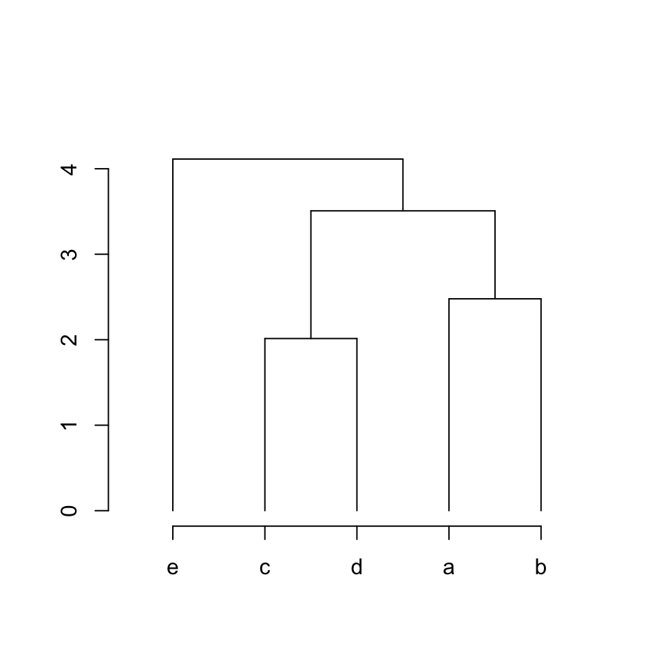

```r
plot(NULL, xlim = c(0.5, 5.5), ylim = c(0, max(hc$height)*1.1), axes = FALSE, ann = FALSE)
axis(side = 1, at = 1:5, labels = hc$labels[hc$order])
axis(side = 2)

segments(x[3], hc$height[1], x[4], hc$height[1])
segments(x[3], 0, x[3], hc$height[1])
segments(x[4], 0, x[4], hc$height[1])

segments(x[1], hc$height[2], x[2], hc$height[2])
segments(x[1], 0, x[1], hc$height[2])
segments(x[2], 0, x[2], hc$height[2])

midpoint = numeric(0)
midpoint[1] = (x[3]+x[4])/2
midpoint[2] = (x[1]+x[2])/2

segments(midpoint[1], hc$height[3], midpoint[2], hc$height[3])
segments(midpoint[1], hc$height[3], midpoint[1], hc$height[1])
segments(midpoint[2], hc$height[3], midpoint[2], hc$height[2])

midpoint[3] = (midpoint[1] + midpoint[2])/2
segments(x[5], hc$height[4], midpoint[3], hc$height[4])
segments(midpoint[3], hc$height[4], midpoint[3], hc$height[3])
segments(x[5], 0, x[5], hc$height[4])
```

为了重复利用上面的代码，我们可以把它们放在一个函数中。这个函数`plot_hc()`很简单，其中四个`if-else`代码块处理下面四个不同的条件：

1. 两个子节点都是变量（或者叶节点）
2. 左子节点是叶节点，右子节点是一个子树
3. 左子节点是一个子树，右子节点是叶节点
4. 两个子节点都是子树

```r
plot_hc = function(hc) {
    x = order(hc$order)
    nobs = length(x)

    if(length(hc$labels) == 0) {
        hc$labels = as.character(seq_along(hc$order))
    }

    plot(NULL, xlim = c(0.5, nobs + 0.5), ylim = c(0, max(hc$height)*1.1), axes = FALSE, ann = FALSE)
    axis(side = 1, at = 1:nobs, labels = hc$labels[hc$order])
    axis(side = 2)

    merge = hc$merge
    order = hc$order
    nr = nrow(merge)
    midpoint = numeric(nr)

    for(i in seq_len(nr)) {
        child1 = merge[i, 1]
        child2 = merge[i, 2]

        if(child1 < 0 && child2 < 0) { # both are leaves
            segments(x[ -child1 ],
                     hc$height[i],
                     x[ -child2 ],
                     hc$height[i])
            midpoint[i] = (x[ -child1 ] + x[ -child2 ])/2
            segments(x[ -child1 ], hc$height[i], x[ -child1 ], 0)
            segments(x[ -child2 ], hc$height[i], x[ -child2 ], 0)
        } else if(child1 < 0 && child2 > 0) {
            segments(x[ -child1 ],
                     hc$height[i],
                     midpoint[ child2 ],
                     hc$height[i])
            midpoint[i] = (x[ -child1 ] + midpoint[ child2 ])/2
            segments(x[ -child1 ], hc$height[i], x[ -child1 ], 0)
            segments(midpoint[ child2 ], hc$height[i], midpoint[ child2 ], hc$height[ child2 ])
        } else if(merge[i, 1] > 0 && merge[i, 2] < 0) {
            segments(midpoint[ child1 ],
                     hc$height[i],
                     x[ -child2 ],
                     hc$height[i])
            midpoint[i] = (midpoint[ child1 ] + x[ -child2 ])/2
            segments(midpoint[ child1 ], hc$height[i], midpoint[ child1 ], hc$height[ child1 ])
            segments(x[ -child2 ], hc$height[i], x[ -child2 ], 0)
        } else {
            segments(midpoint[ child1 ],
                     hc$height[i],
                     midpoint[ child2 ],
                     hc$height[i])
            midpoint[i] = (midpoint[ child1 ] + midpoint[ child2 ])/2
            segments(midpoint[ child1 ], hc$height[i], midpoint[ child1 ], hc$height[ child1 ])
            segments(midpoint[ child2 ], hc$height[i], midpoint[ child2 ], hc$height[ child2 ])
        }
    }
}
```

我们试一试这个函数：

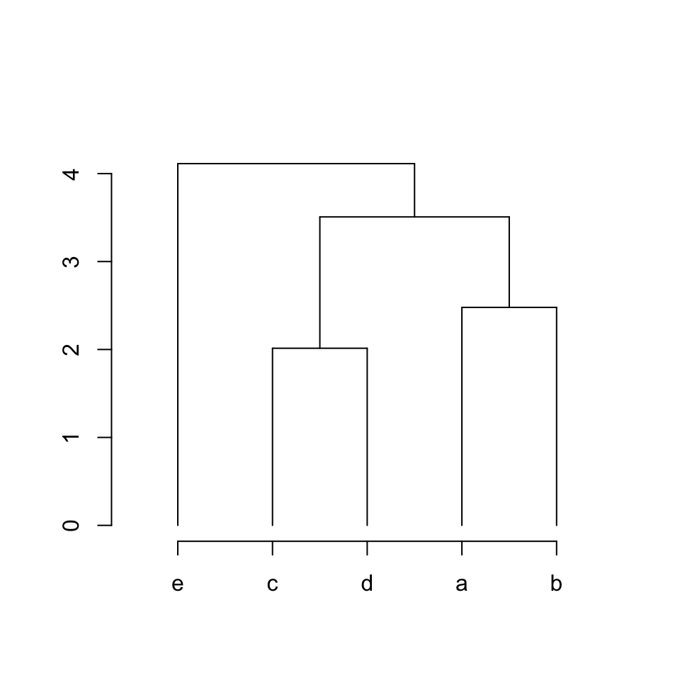

```r
plot_hc(hc)
```

或者试一个更大的聚类结果：

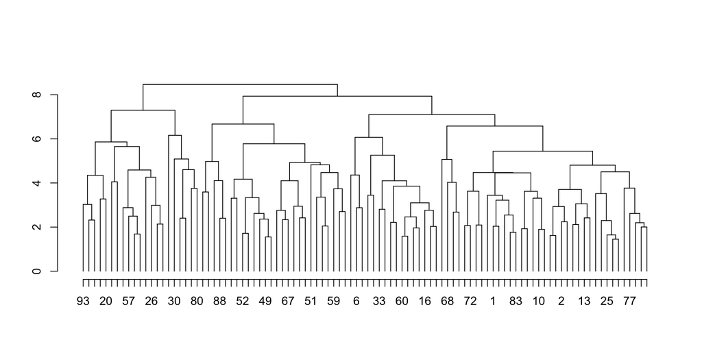

```r
m2 = matrix(rnorm(1000), nrow = 100)
hc2 = hclust(dist(m2))
plot_hc(hc2)
```

到这里，通常我们会有很大的成就感。因为`plot_hc()`是基于一个微小的数据测试和编写的，现在居然在很大的数据上能够成功运行。

下面我们来看，给定一个父节点(`top_x`, `top_y`)，和两个子节点(`left_x`, `left_y`)，(`right_x`, `right_y`)，我们来定义如何连接这三个节点。

默认的连接方式是连接下面四个点：

```
x-coordinates: left_x, left_x, right_x, right_x
y-coordinates: left_y, top_y, top_y, right_y
```

在`plot_hc()`中，让我们将绘制父节点和子节点的代码抽象化。我们引入一个函数`parent_children_connections()`，其中我们可以自定义如何绘制连接方式。

```r
plot_hc = function(hc) {
    x = order(hc$order)
    nobs = length(x)

    if(length(hc$labels) == 0) {
        hc$labels = as.character(seq_along(hc$order))
    }

    plot(NULL, xlim = c(0.5, nobs + 0.5), ylim = c(0, max(hc$height)*1.1), axes = FALSE, ann = FALSE)
    axis(side = 1, at = 1:nobs, labels = hc$labels[hc$order])
    axis(side = 2)

    merge = hc$merge
    order = hc$order
    height = hc$height
    nr = nrow(merge)
    midpoint = numeric(nr)

    for(i in seq_len(nr)) {
        child1 = merge[i, 1]
        child2 = merge[i, 2]

        if(child1 < 0 && child2 < 0) { # both are leaves
            midpoint[i] = (x[ -child1 ] + x[ -child2 ])/2
            parent_children_connections(
                x[-child1], 0,
                midpoint[i], height[i],
                x[-child2], 0
            )
        } else if(child1 < 0 && child2 > 0) {
            midpoint[i] = (x[ -child1 ] + midpoint[ child2 ])/2
            parent_children_connections(
                x[-child1], 0,
                midpoint[i], height[i],
                midpoint[child2], height[child2]
            )
        } else if(child1 > 0 && child2 < 0) {
            midpoint[i] = (midpoint[ child1 ] + x[ -child2 ])/2
            parent_children_connections(
                midpoint[child1], height[child1],
                midpoint[i], height[i],
                x[-child2], 0
            )
        } else {
            midpoint[i] = (midpoint[ child1 ] + midpoint[ child2 ])/2
            parent_children_connections(
                midpoint[child1], height[child1],
                midpoint[i], height[i],
                midpoint[child2], height[child2]
            )
        }
    }
}
```

下面是默认的连接父节点和两个子节点的方式：

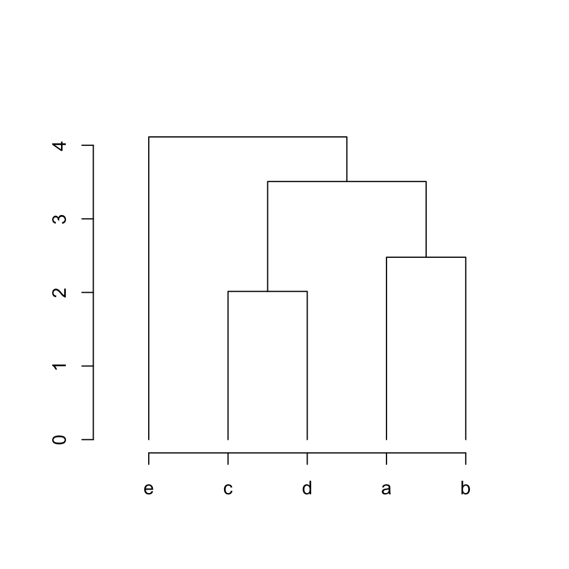

```r
parent_children_connections = function(left_x, left_y, top_x, top_y, right_x, right_y) {
    lines(c(left_x, left_x, right_x, right_x),
          c(left_y, top_y, top_y, right_y))
}
plot_hc(hc)
```

我们可以定义一个新的方式，让连接方式呈三角形状：

```
x-coordinates: left_x, top_x, right_x
y-coordinates: left_y, top_y, right_y
```

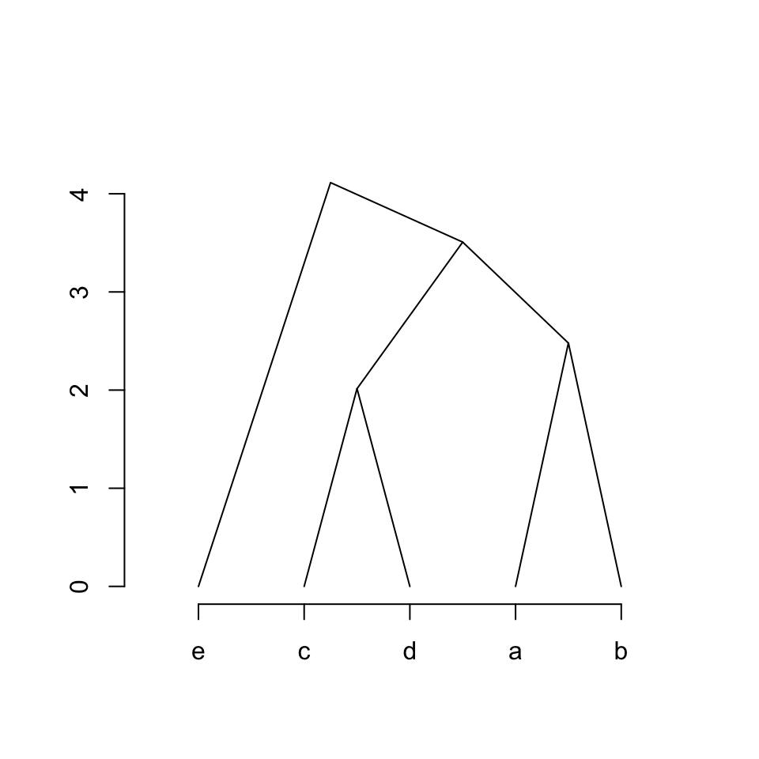

```r
parent_children_connections = function(left_x, left_y, top_x, top_y, right_x, right_y) {
    lines(c(left_x, top_x, right_x),
          c(left_y, top_y, right_y))
}
plot_hc(hc)
```

同理，你可以自定义`parent_children_connections()`来实现其他连接方式，例如使用贝泽尔曲线。

本文使用 [CC BY-NC-SA 4.0](https://creativecommons.org/licenses/by-nc-sa/4.0/deed.zh-hans) 协议发布。